# Correspondence Analysis

Maciej Beręsewicz

# Setting for notebook

```r
library(reticulate)
use_python("/usr/local/anaconda3/bin/python")
```

```r
knitr::opts_chunk$set(engine.path = list(
  python = "/usr/local/anaconda3/bin/python",
  julia = "/Applications/Julia-1.3.app/Contents/Resources/julia/bin/"
))
```

# Correspondence analysis

## Correspondence analysis in R

```r
library(vcd)
```

Data for the lecture

```r
data_vec <- c(1933, 1175, 1186, 646, 579, 671, 707, 780, 767, 768, 962, 1126)
data_mat <- matrix(data = data_vec, nrow = 4, ncol = 3, byrow = T)
rownames(data_mat) <- c("Rural", "city 20k", "city 20k-100k", "city 100k+")
colnames(data_mat) <- c("Realised","Refusals","Errors")
data_mat
```

```
              Realised Refusals Errors
Rural             1933     1175   1186
city 20k           646      579    671
city 20k-100k      707      780    767
city 100k+         768      962   1126
```

In order to verify whether the correspondence analysis may be applied one should follow the steps:

1. verify relationship (using $\chi^2$ test)
2. verify correlation (using Cramers’ V statistic)
3. proceed with correspondence analysis

```r
chisq.test(data_mat)
```

```
    Pearson's Chi-squared test

data:  data_mat
X-squared = 290.2, df = 6, p-value < 2.2e-16
```

```r
chisq.test(data_mat, correct = T) ## Yates' correction
```

```
    Pearson's Chi-squared test

data:  data_mat
X-squared = 290.2, df = 6, p-value < 2.2e-16
```

```r
assocstats(data_mat)
```

```
                    X^2 df P(> X^2)
Likelihood Ratio 290.04  6        0
Pearson          290.20  6        0

Phi-Coefficient   : NA
Contingency Coeff.: 0.158
Cramer's V        : 0.113
```

```r
prop.table(data_mat, 1)
```

```
               Realised  Refusals    Errors
Rural         0.4501630 0.2736376 0.2761993
city 20k      0.3407173 0.3053797 0.3539030
city 20k-100k 0.3136646 0.3460515 0.3402839
city 100k+    0.2689076 0.3368347 0.3942577
```

To conduct the correspondence analysis in R we can use function `ca` from the package `ca`.

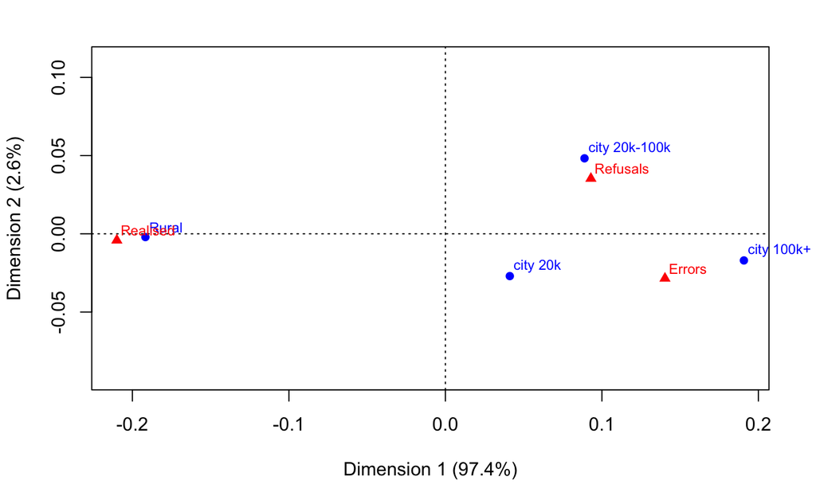

```r
result <- ca(data_mat)
plot(result)
```

```r
result
```

```
 Principal inertias (eigenvalues):
           1       2
Value      0.02502 0.000662
Percentage 97.42%  2.58%


 Rows:
            Rural  city 20k city 20k-100k city 100k+
Mass     0.380000  0.167788      0.199469   0.252743
ChiDist  0.191706  0.049230      0.101139   0.191503
Inertia  0.013965  0.000407      0.002040   0.009269
Dim. 1  -1.211908  0.260156      0.561935   1.205908
Dim. 2  -0.080827 -1.050377      1.875721  -0.661515


 Columns:
         Realised Refusals    Errors
Mass     0.358761 0.309381  0.331858
ChiDist  0.209989 0.099462  0.143158
Inertia  0.015820 0.003061  0.006801
Dim. 1  -1.327312 0.587780  0.886945
Dim. 2  -0.160041 1.373601 -1.107548
```

```r
summary(result)
```

```
Principal inertias (eigenvalues):

 dim    value      %   cum%   scree plot
 1      0.025020  97.4  97.4  ************************
 2      0.000662   2.6 100.0  *
        -------- -----
 Total: 0.025681 100.0


Rows:
    name   mass  qlt  inr    k=1  cor ctr    k=2 cor ctr
1 | Rurl |  380 1000  544 | -192 1000 558 |   -2   0   2 |
2 | ct20 |  168 1000   16 |   41  699  11 |  -27 301 185 |
3 | c201 |  199 1000   79 |   89  772  63 |   48 228 702 |
4 | c100 |  253 1000  361 |  191  992 368 |  -17   8 111 |

Columns:
    name   mass  qlt  inr    k=1  cor ctr    k=2 cor ctr
1 | Rlsd |  359 1000  616 | -210 1000 632 |   -4   0   9 |
2 | Rfsl |  309 1000  119 |   93  874 107 |   35 126 584 |
3 | Errr |  332 1000  265 |  140  960 261 |  -28  40 407 |
```

Read the data about shops and factors that drove respondents to select these shops

| Sklep | Powod | Plec | Wiek |
| --- | --- | --- | --- |
| Real | Location | K | od25do30 |
| Auchan | Promos | K | od40do49 |
| Agent | Location | K | od31do39 |
| Agent | Promos | K | od50do59 |
| Auchan | OpeningHours | K | od25do30 |
| Real | Promos | K | od40do49 |
| Agent | Location | K | od40do49 |
| Carrefour | Selection | K | od25do30 |
| Real | Selection | K | od40do49 |
| Auchan | Selection | K | od31do39 |

[output cut: 152 more lines]

```r
shops_tab
```

```
             Powod
Sklep         Promos Quality Location OpeningHours Prices Selection Reach
  Auchan           4       1        3            1      4        12     2
  Albert           2       0        4            1      0         1     0
  Biedronka        2       0        5            0     21         1     0
  Carrefour        2       1        0            1      0         3     1
  Agent            4       1        4            3      1         5     4
  Hypernova        1       0        1            0      1         3     1
  inn              0       1        9            4      1         1     2
  LeaderPrice      0       0        1            0      7         1     0
  Real             7       1        8            4      2        12     0
```

```r
chisq.test(shops_tab, correct = T)
```

```
Chi-squared approximation may be incorrect
```

```
    Pearson's Chi-squared test

data:  shops_tab
X-squared = 122.45, df = 48, p-value = 1.974e-08
```

```r
assocstats(shops_tab)
```

```
                    X^2 df   P(> X^2)
Likelihood Ratio 126.40 48 5.5958e-09
Pearson          122.45 48 1.9740e-08

Phi-Coefficient   : NA
Contingency Coeff.: 0.656
Cramer's V        : 0.355
```

1. why there is dependence in the data?
2. what factors correspond with which shops?
3. are there cluster of shops?
4. what are the main factors that drove respondents to select given shop?

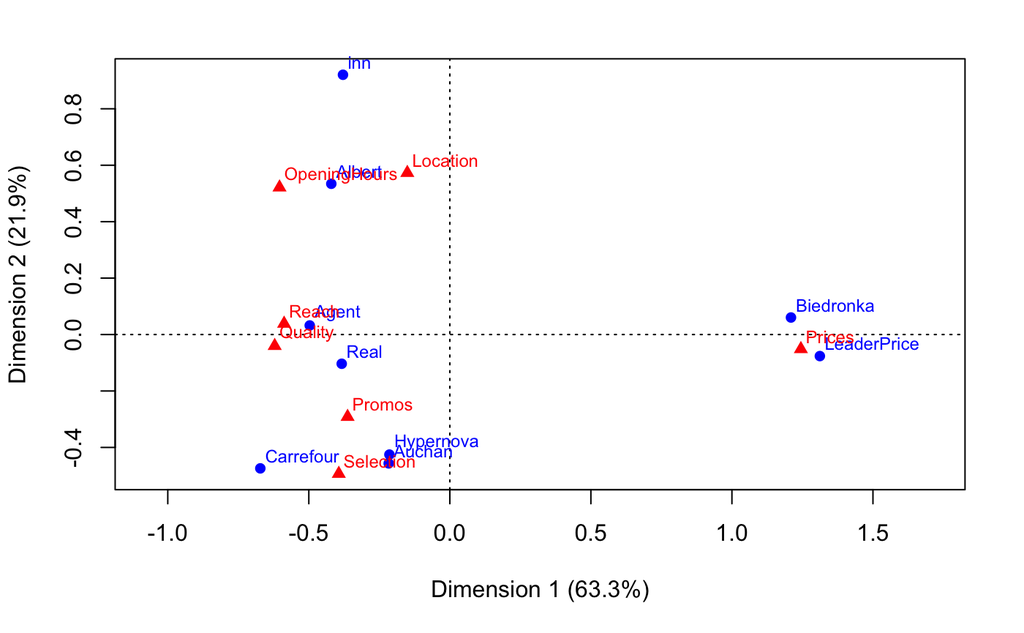

```r
summary(shops_ca)
```

```
Principal inertias (eigenvalues):

 dim    value      %   cum%   scree plot
 1      0.478566  63.3  63.3  ****************
 2      0.165270  21.9  85.2  *****
 3      0.070426   9.3  94.5  **
 4      0.021350   2.8  97.3  *
 5      0.017907   2.4  99.7  *
 6      0.002350   0.3 100.0
        -------- -----
 Total: 0.755870 100.0


Rows:
    name   mass  qlt  inr    k=1 cor ctr    k=2 cor ctr
1 | Achn |  167  898   63 | -217 165  16 | -457 732 210 |
2 | Albr |   49  535   56 | -420 205  18 |  534 331  85 |
3 | Bdrn |  179  995  349 | 1209 993 547 |   60   2   4 |
4 | Crrf |   49  687   64 | -672 459  47 | -474 228  67 |
5 | Agnt |  136  566   79 | -497 564  70 |   32   2   1 |
6 | Hypr |   43  531   24 | -214 107   4 | -425 423  47 |
7 |  inn |  111  939  155 | -379 136  33 |  920 803 570 |
8 | LdrP |   56  983  129 | 1312 979 200 |  -76   3   2 |
9 | Real |  210  545   80 | -383 508  64 | -104  37  14 |

Columns:
    name   mass  qlt  inr    k=1 cor ctr    k=2 cor ctr
1 | Prms |  136  613   63 | -363 373  37 | -291 241  70 |
2 | Qlty |   31  433   37 | -621 431  25 |  -40   2   0 |
3 | Lctn |  216  886  113 | -151  57  10 |  573 828 429 |
4 | OpnH |   86  911   80 | -604 522  66 |  522 389 142 |
5 | Prcs |  228  997  470 | 1245 995 739 |  -51   2   4 |
6 | Slct |  241  923  137 | -394 359  78 | -493 563 354 |
7 | Rech |   62  286   99 | -588 285  45 |   39   1   1 |
```

Follow the example about ages and tv stations

```r
vec <- c(26, 10, 40, 44, 18, 14, 15, 12, 21)
tab <- matrix(data = vec, nrow = 3, byrow = T)
colnames(tab) <- c("tvp1", "polsat", "tvn")
rownames(tab) <- c("<20","20-35", "35+")
chisq.test(tab)
```

```
    Pearson's Chi-squared test

data:  tab
X-squared = 22.309, df = 4, p-value = 0.000174
```

```r
sum(tab)
```

```
[1] 200
```

```r
result_tv <- ca(tab)
result_tv
```

```
 Principal inertias (eigenvalues):
           1        2
Value      0.101099 0.010444
Percentage 90.64%   9.36%


 Rows:
              <20     20-35       35+
Mass     0.380000  0.380000  0.240000
ChiDist  0.317227  0.399524  0.229556
Inertia  0.038240  0.060655  0.012647
Dim. 1  -0.960259  1.254102 -0.465251
Dim. 2  -0.842307 -0.242504  1.717617


 Columns:
             tvp1   polsat       tvn
Mass     0.425000 0.200000  0.375000
ChiDist  0.284838 0.269014  0.408535
Inertia  0.034481 0.014474  0.062588
Dim. 1   0.859707 0.580908 -1.284153
Dim. 2  -0.783482 1.913778 -0.132735
```

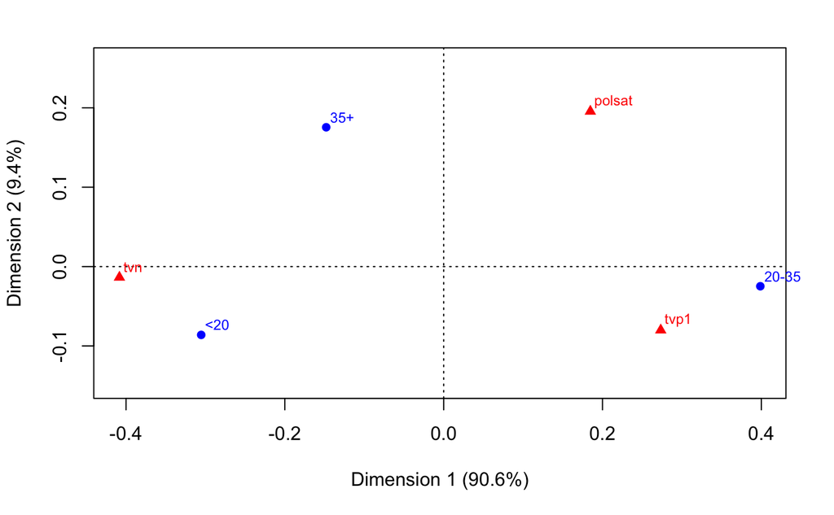

```r
plot(result_tv)
```

## Correspondence analysis in Python

To conduct correspondence analysis we need to install module `prince` (https://github.com/MaxHalford/prince) or we may implement the correspondence analysis by ourselves

```python
import prince
import pandas as pd
```

Take the data

[output not shown]

Define settings for correspondence analysis

[output not shown]

[output not shown]

The main important elements

col_masses_ row_masses_ column_coordinates row_coordinates eigenvalues_ explained_inertia_ total_inertia_

```
[0.9742271923003916, 0.025772807699608553]
```

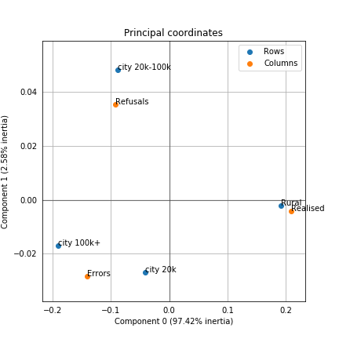

## Correspondence analysis in Julia

We need to implement correspondence analysis by ourselves.

We start with loading library for Linear Algebra and define our own functions resembling R `rowSums` and `colSums`.

```
## Plots.GRBackend()
```

Nest, we impelement step by step correspondence analysis using SVD algorithm

```
## ca (generic function with 1 method)
```

```
## 4×3 Array{Int64,2}:
##  1933  1175  1186
##   646   579   671
##   707   780   767
##   768   962  1126
```

```
## ---------- row coords ----------


## 4×2 Array{Float64,2}:
##  -0.191694   -0.00207945
##   0.0411504  -0.0270231
##   0.0888845   0.0482568
##   0.190745   -0.0170189

## ---------- col coords ----------


## 3×2 Array{Float64,2}:
##  -0.209949   -0.00411738
##   0.0929726   0.0353387
##   0.140293   -0.028494
```

```
## 7×4 DataFrame
## │ Row │ x1        │ x2          │ label         │ color  │
## │     │ Float64   │ Float64     │ String        │ String │
## ├─────┼───────────┼─────────────┼───────────────┼────────┤
## │ 1   │ -0.191694 │ -0.00207945 │ Rural         │ red    │
## │ 2   │ 0.0411504 │ -0.0270231  │ city 20k      │ red    │
## │ 3   │ 0.0888845 │ 0.0482568   │ city 20k-100k │ red    │
## │ 4   │ 0.190745  │ -0.0170189  │ city 100k+    │ red    │
## │ 5   │ -0.209949 │ -0.00411738 │ Realised      │ blue   │
## │ 6   │ 0.0929726 │ 0.0353387   │ Refusals      │ blue   │
## │ 7   │ 0.140293  │ -0.028494   │ Errors        │ blue   │
```

```
## Plot{Plots.GRBackend() n=1}
```